# Regression

The data is taken from site https://data.fivethirtyeight.com/.

```python
#import CSV file
import pandas as pd
```

```python
from google.colab import files
```

```python
file = files.upload()
```

Upload widget is only available when the cell has been executed in the current browser session. Please rerun this cell to enable.

```
Saving mlb_elo_latest.csv to mlb_elo_latest (1).csv
```

```python
#Read CSV file
import io
data = pd.read_csv(io.BytesIO(file['mlb_elo_latest.csv']))
```

Let's display few rows of data and dimension of the data

```python
print(data.head)
```

```
<bound method NDFrame.head of             date  season  neutral  ... rating2_post score1 score2
0     2019-10-30    2019        0  ...  1583.382133      2      6
1     2019-10-29    2019        0  ...  1580.329587      2      7
2     2019-10-27    2019        0  ...  1595.165625      1      7
3     2019-10-26    2019        0  ...  1592.633477      1      8
4     2019-10-25    2019        0  ...  1587.640180      1      4
...          ...     ...      ...  ...          ...    ...    ...
2461  2019-03-28    2019        0  ...  1524.424808      5      4
2462  2019-03-28    2019        0  ...  1524.171277      0      2
2463  2019-03-28    2019        0  ...  1420.675155      7      2
2464  2019-03-21    2019        1  ...  1493.483066      4      5
2465  2019-03-20    2019        1  ...  1492.270839      7      9

[2466 rows x 26 columns]>
```

Let's now find out the missing value in the data

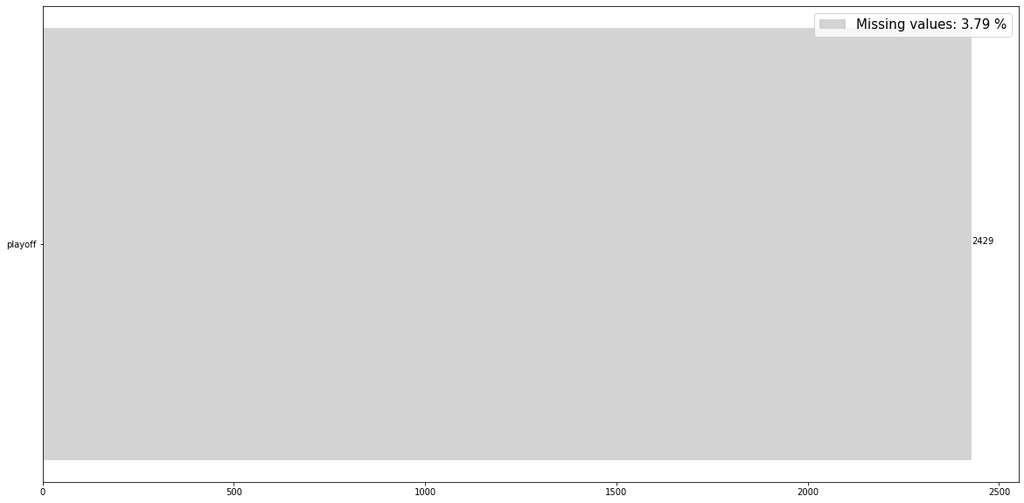

```python
#Finding missing values
#!pip install draw_missing
import drawmissing as d
o = d.Draw(data)
o.draw_missing_plot()
```

We can see from above graph that 3.79% of total data is missing and out of 2466 rows 2429 rows are missing from the column playoffs. So, it is better to drop thi column as it is of no use.

```python
data = data.drop(columns='playoff')
```

```python
print(data.head)
print(data.shape)
```

```
<bound method NDFrame.head of             date  season  neutral  ... rating2_post score1  score2
0     2019-10-30    2019        0  ...  1583.382133      2       6
1     2019-10-29    2019        0  ...  1580.329587      2       7
2     2019-10-27    2019        0  ...  1595.165625      1       7
3     2019-10-26    2019        0  ...  1592.633477      1       8
4     2019-10-25    2019        0  ...  1587.640180      1       4
...          ...     ...      ...  ...          ...    ...     ...
2461  2019-03-28    2019        0  ...  1524.424808      5       4
2462  2019-03-28    2019        0  ...  1524.171277      0       2
2463  2019-03-28    2019        0  ...  1420.675155      7       2
2464  2019-03-21    2019        1  ...  1493.483066      4       5
2465  2019-03-20    2019        1  ...  1492.270839      7       9

[2466 rows x 25 columns]>
(2466, 25)
```

There are too many columns in out dataset which can affect our classification model. Therefore let's remove some of the least related columns to make data appropriate for classification.

```python
from matplotlib import pyplot
```

```
              season   neutral  elo1_pre  ...  rating2_post    score1    score2
season           NaN       NaN       NaN  ...           NaN       NaN       NaN
neutral          NaN  1.000000  0.000249  ...      0.037043  0.015728  0.074106
elo1_pre         NaN  0.000249  1.000000  ...     -0.030491  0.130259 -0.145773
elo2_pre         NaN  0.036496 -0.020434  ...      0.972028 -0.088338  0.108883
elo_prob1        NaN -0.050579  0.717764  ...     -0.696995  0.152528 -0.180031
elo_prob2        NaN  0.050579 -0.717764  ...      0.696995 -0.152528  0.180031
elo1_post        NaN -0.001706  0.998338  ...     -0.033339  0.165568 -0.184064
elo2_post        NaN  0.038374 -0.022758  ...      0.972953 -0.124005  0.147553
rating1_pre      NaN -0.001865  0.971979  ...     -0.044597  0.131727 -0.162216
rating2_pre      NaN  0.035814 -0.028847  ...      0.999152 -0.089709  0.109498
pitcher1_rgs     NaN -0.034265  0.422927  ...     -0.000742  0.051637 -0.123811
pitcher2_rgs     NaN  0.024515 -0.005971  ...      0.461493 -0.120163  0.015499
pitcher1_adj     NaN -0.025854 -0.029494  ...      0.027566 -0.020689 -0.068810
pitcher2_adj     NaN  0.018950  0.024162  ...     -0.010879 -0.064960 -0.031798
rating_prob1     NaN -0.058666  0.649949  ...     -0.673531  0.156981 -0.190263
rating_prob2     NaN  0.058666 -0.649949  ...      0.673531 -0.156981  0.190263
rating1_post     NaN -0.003114  0.970867  ...     -0.046115  0.156645 -0.189236
rating2_post     NaN  0.037043 -0.030491  ...      1.000000 -0.115002  0.136971
score1           NaN  0.015728  0.130259  ...     -0.115002  1.000000  0.022551
score2           NaN  0.074106 -0.145773  ...      0.136971  0.022551  1.000000

[20 rows x 20 columns]
```

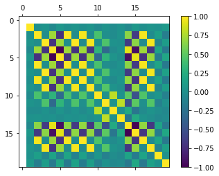

```python
cor = data.corr()
print(cor)
plt = pyplot.figure()
x = plt.add_subplot(111)
y = x.matshow(cor, vmin=-1, vmax=1)
plt.colorbar(y)
pyplot.show()
```

As there is no corelation betweeen of season with any column we remove that column.

```python
data = data.drop(columns= 'season')
```

For regression we are going to split the data into two datasets. Team1 data and Team2 data. Model will be fit on team1 data and will be evaluated on team2 data.

```python
team1_data  = data[['elo1_pre','elo_prob1','elo1_post','rating1_pre','pitcher1_rgs','pitcher1_adj','rating_prob1','rating1_post','score2','score1']]
```

```python
print(team1_data)
```

```
         elo1_pre  elo_prob1    elo1_post  ...  rating1_post  score2  score1
0     1599.542804   0.574617  1594.882297  ...   1587.973463       6       2
1     1605.069000   0.595209  1599.542804  ...   1591.026009       7       2
2     1584.005206   0.515546  1578.837182  ...   1576.189971       7       1
3     1589.985555   0.538425  1584.005206  ...   1578.722119       8       1
4     1593.827376   0.553044  1589.985555  ...   1583.715416       4       1
...           ...        ...          ...  ...           ...     ...     ...
2461  1539.739468   0.560411  1540.955109  ...   1530.115045       4       5
2462  1515.935946   0.558821  1513.801421  ...   1534.830993       2       0
2463  1543.454311   0.663576  1545.161285  ...   1569.956639       2       7
2464  1538.451430   0.539971  1536.797652  ...   1517.909603       5       4
2465  1540.662576   0.546288  1538.451430  ...   1519.121831       9       7

[2466 rows x 10 columns]
```

```python
team2_data = data[['elo2_pre','elo_prob2','elo2_post','rating2_pre','pitcher2_rgs','pitcher2_adj','rating_prob2','rating2_post','score1','score2']]
```

```python
team2_data
```

|  | elo2_pre | elo_prob2 | elo2_post | rating2_pre | pitcher2_rgs | pitcher2_adj | rating_prob2 | rating2_post | score1 | score2 |
| --- | --- | --- | --- | --- | --- | --- | --- | --- | --- | --- |
| 0 | 1584.363378 | 0.425383 | 1589.023885 | 1580.329587 | 61.723620 | 27.776342 | 0.484828 | 1583.382133 | 2 | 6 |
| 1 | 1578.837182 | 0.404791 | 1584.363378 | 1576.189971 | 60.272516 | 21.776276 | 0.405362 | 1580.329587 | 2 | 7 |
| 2 | 1599.900976 | 0.484454 | 1605.069000 | 1592.633477 | 66.891460 | 47.888341 | 0.626898 | 1595.165625 | 1 | 7 |
| 3 | 1593.920627 | 0.461575 | 1599.900976 | 1587.640180 | 51.251046 | -24.893480 | 0.413026 | 1592.633477 | 1 | 8 |
| 4 | 1590.078806 | 0.446956 | 1593.920627 | 1584.926863 | 57.096801 | 2.440389 | 0.473148 | 1587.640180 | 1 | 4 |
| ... | ... | ... | ... | ... | ... | ... | ... | ... | ... | ... |
| 2461 | 1521.555882 | 0.439589 | 1520.340242 | 1525.399509 | 55.476658 | 20.032738 | 0.463973 | 1524.424808 | 5 | 4 |
| 2462 | 1498.872967 | 0.441179 | 1501.007492 | 1522.655780 | 65.144625 | 52.342542 | 0.470457 | 1524.171277 | 0 | 2 |
| 2463 | 1449.452572 | 0.336424 | 1447.745598 | 1421.447637 | 44.195773 | -11.670645 | 0.242628 | 1420.675155 | 7 | 2 |
| 2464 | 1510.617249 | 0.460029 | 1512.271027 | 1492.270839 | 47.400000 | -3.155546 | 0.470664 | 1493.483066 | 4 | 5 |
| 2465 | 1508.406103 | 0.453712 | 1510.617249 | 1490.581534 | 50.290116 | 10.194364 | 0.450971 | 1492.270839 | 7 | 9 |

2466 rows × 10 columns

Now we plot heat map for both team1 data and team2 data.

```
              elo1_pre  elo_prob1  elo1_post  ...  rating1_post    score2    score1
elo1_pre      1.000000   0.717764   0.998338  ...      0.970867 -0.145773  0.130259
elo_prob1     0.717764   1.000000   0.716859  ...      0.709271 -0.180031  0.152528
elo1_post     0.998338   0.716859   1.000000  ...      0.972617 -0.184064  0.165568
rating1_pre   0.971979   0.710047   0.971379  ...      0.999159 -0.162216  0.131727
pitcher1_rgs  0.422927   0.303873   0.424618  ...      0.448197 -0.123811  0.051637
pitcher1_adj -0.029494  -0.033645  -0.027070  ...     -0.033528 -0.068810 -0.020689
rating_prob1  0.649949   0.915201   0.651017  ...      0.675645 -0.190263  0.156981
rating1_post  0.970867   0.709271   0.972617  ...      1.000000 -0.189236  0.156645
score2       -0.145773  -0.180031  -0.184064  ...     -0.189236  1.000000  0.022551
score1        0.130259   0.152528   0.165568  ...      0.156645  0.022551  1.000000

[10 rows x 10 columns]
```

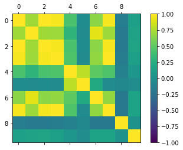

```python
cor = team1_data.corr()
print(cor)
plt = pyplot.figure()
x = plt.add_subplot(111)
y = x.matshow(cor, vmin=-1, vmax=1)
plt.colorbar(y)
pyplot.show()
```

```
              elo2_pre  elo_prob2  elo2_post  ...  rating2_post    score1    score2
elo2_pre      1.000000   0.709334   0.998333  ...      0.972028 -0.088338  0.108883
elo_prob2     0.709334   1.000000   0.709827  ...      0.696995 -0.152528  0.180031
elo2_post     0.998333   0.709827   1.000000  ...      0.972953 -0.124005  0.147553
rating2_pre   0.972698   0.696299   0.971259  ...      0.999152 -0.089709  0.109498
pitcher2_rgs  0.440013   0.308940   0.441230  ...      0.461493 -0.120163  0.015499
pitcher2_adj  0.000894  -0.017517   0.002661  ...     -0.010879 -0.064960 -0.031798
rating_prob2  0.655248   0.915201   0.657555  ...      0.673531 -0.156981  0.190263
rating2_post  0.972028   0.696995   0.972953  ...      1.000000 -0.115002  0.136971
score1       -0.088338  -0.152528  -0.124005  ...     -0.115002  1.000000  0.022551
score2        0.108883   0.180031   0.147553  ...      0.136971  0.022551  1.000000

[10 rows x 10 columns]
```

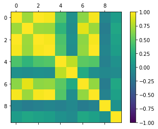

```python
cor = team2_data.corr()
print(cor)
plt = pyplot.figure()
x = plt.add_subplot(111)
y = x.matshow(cor, vmin=-1, vmax=1)
plt.colorbar(y)
pyplot.show()
```

From both th heat maps we can see that there is no dark blue or violet cell. So we can use these both as our training testing dataset.

Defining Input and output variables for training dataset.

```python
input1 = team1_data.iloc[:,0:9]
output1 = team1_data.iloc[:,-1]
```

```python
input1
```

|  | elo1_pre | elo_prob1 | elo1_post | rating1_pre | pitcher1_rgs | pitcher1_adj | rating_prob1 | rating1_post | score2 |
| --- | --- | --- | --- | --- | --- | --- | --- | --- | --- |
| 0 | 1599.542804 | 0.574617 | 1594.882297 | 1591.026009 | 56.920649 | 0.989236 | 0.515172 | 1587.973463 | 6 |
| 1 | 1605.069000 | 0.595209 | 1599.542804 | 1595.165625 | 62.975093 | 28.723451 | 0.594638 | 1591.026009 | 7 |
| 2 | 1584.005206 | 0.515546 | 1578.837182 | 1578.722119 | 49.433198 | -29.811205 | 0.373102 | 1576.189971 | 7 |
| 3 | 1589.985555 | 0.538425 | 1584.005206 | 1583.715416 | 56.003581 | 0.823752 | 0.586974 | 1578.722119 | 8 |
| 4 | 1593.827376 | 0.553044 | 1589.985555 | 1586.428733 | 54.036365 | -9.053908 | 0.526852 | 1583.715416 | 4 |
| ... | ... | ... | ... | ... | ... | ... | ... | ... | ... |
| 2461 | 1539.739468 | 0.560411 | 1540.955109 | 1529.140344 | 54.035982 | 16.056535 | 0.536027 | 1530.115045 | 4 |
| 2462 | 1515.935946 | 0.558821 | 1513.801421 | 1536.346491 | 62.669388 | 36.897491 | 0.529543 | 1534.830993 | 2 |
| 2463 | 1543.454311 | 0.663576 | 1545.161285 | 1569.184157 | 55.851946 | 12.596364 | 0.757372 | 1569.956639 | 2 |
| 2464 | 1538.451430 | 0.539971 | 1536.797652 | 1519.121831 | 45.343580 | -9.598335 | 0.529336 | 1517.909603 | 5 |
| 2465 | 1540.662576 | 0.546288 | 1538.451430 | 1520.811136 | 50.867044 | 15.661717 | 0.549029 | 1519.121831 | 9 |

2466 rows × 9 columns

```python
output1
```

```
0       2
1       2
2       1
3       1
4       1
       ..
2461    5
2462    0
2463    7
2464    4
2465    7
Name: score1, Length: 2466, dtype: int64
```

Defining Team2_data

```python
input2 = team2_data.iloc[:,0:9]
output2 = team2_data.iloc[:,-1]
```

```python
input2
```

|  | elo2_pre | elo_prob2 | elo2_post | rating2_pre | pitcher2_rgs | pitcher2_adj | rating_prob2 | rating2_post | score1 |
| --- | --- | --- | --- | --- | --- | --- | --- | --- | --- |
| 0 | 1584.363378 | 0.425383 | 1589.023885 | 1580.329587 | 61.723620 | 27.776342 | 0.484828 | 1583.382133 | 2 |
| 1 | 1578.837182 | 0.404791 | 1584.363378 | 1576.189971 | 60.272516 | 21.776276 | 0.405362 | 1580.329587 | 2 |
| 2 | 1599.900976 | 0.484454 | 1605.069000 | 1592.633477 | 66.891460 | 47.888341 | 0.626898 | 1595.165625 | 1 |
| 3 | 1593.920627 | 0.461575 | 1599.900976 | 1587.640180 | 51.251046 | -24.893480 | 0.413026 | 1592.633477 | 1 |
| 4 | 1590.078806 | 0.446956 | 1593.920627 | 1584.926863 | 57.096801 | 2.440389 | 0.473148 | 1587.640180 | 1 |
| ... | ... | ... | ... | ... | ... | ... | ... | ... | ... |
| 2461 | 1521.555882 | 0.439589 | 1520.340242 | 1525.399509 | 55.476658 | 20.032738 | 0.463973 | 1524.424808 | 5 |
| 2462 | 1498.872967 | 0.441179 | 1501.007492 | 1522.655780 | 65.144625 | 52.342542 | 0.470457 | 1524.171277 | 0 |
| 2463 | 1449.452572 | 0.336424 | 1447.745598 | 1421.447637 | 44.195773 | -11.670645 | 0.242628 | 1420.675155 | 7 |
| 2464 | 1510.617249 | 0.460029 | 1512.271027 | 1492.270839 | 47.400000 | -3.155546 | 0.470664 | 1493.483066 | 4 |
| 2465 | 1508.406103 | 0.453712 | 1510.617249 | 1490.581534 | 50.290116 | 10.194364 | 0.450971 | 1492.270839 | 7 |

2466 rows × 9 columns

```python
output2
```

```
0       6
1       7
2       7
3       8
4       4
       ..
2461    4
2462    2
2463    2
2464    5
2465    9
Name: score2, Length: 2466, dtype: int64
```

Importing the models

```python
from sklearn.linear_model import LinearRegression
from sklearn import metrics
from sklearn.metrics import r2_score
import numpy as np
```

Fitting the model

```python
mod = LinearRegression()
res = mod.fit(input1,output1)
```

Predicting the values

```python
predicted_score = mod.predict(input2)
print(predicted_score)
```

```
[ 9.31951235 10.19324765 10.58372926 ...  2.1975887   6.23732059
  9.51191141]
```

Evaluating the model using RMSE and R sqaaured error

```python
#RMSE for model
print('Root Mean Squared Error with linear regression:', np.sqrt(metrics.mean_squared_error(output2, predicted_score)))
#rsquared error
print('R-sqared Error with linear regression:', mod.score(input2,output2))
```

```
Root Mean Squared Error with linear regression: 1.4045680966051854
R-sqared Error with linear regression: 0.8312369664157662
```